# jjmTools

SPRFMO’s Scientific Committee

Thursday, August 28, 2014

Paquete con herramientas para el análisis y obtención de resultados a partir de las salidas del Joint Jack Mackerel Model (JJM). Este paquete cuenta en la actualidad con dos funciones:

`readJJM`: Tomaa una ruta (la ruta de la carpeta **admb** dentro de la carpeta repositorio) y el nombre de un modelo o lista de modelos a evaluar. Devuelve un objeto de clase **jjm.output** (para un modelo único) o **jjm.lstOuts** (para una lista de modelos)

`diagnostics`: Toma un objeto de tipo **jjm.output** y genera gráficos a partir de los datos que este contenga. Internamente la función requiere de la existencia de los archivos de datos del modelo (.dat), de configuración (.ctl), de salidas para R (_R.rep) y de rendimiento (.yld). Devuelve una lista de gráficos de clase jjm.diag.

Por otro lado, y dado que se obtienen objetos de clases jjm.output, jjm.lstOuts y jjm.diag, el paquete contempla la definición de los métodos correspondientes para las funciones `print`, `summary` y `plot`.

El script de demostración *jjmTools.R* (dentro de la carpeta “demo”) puede ser copiado y ejecutado directamente desde dentro de la carpeta **admb** (en el repositorio)

A continuación, se detallarán las funciones y salidas de las funciones de **jjmTools**: Se inicia con la definición de parámetros:

**1.** Cargar el paquete usando el comando `require`. jjmTools tiene como paquetes dependientes a *lattice*, *PBSadmb* y *PBSmodelling*, por lo que es necesario instalarlos previamente para evitar posibles mensajes de error. Para cargar jjmTools basta con usar el siguiente comando:

`require(jjmTools)`

```r
require(jjmTools)
```

**2.** Directorio raíz de JJM, definido en un objeto (en el ejemplo `reposDir`). La función admite rutas relativas (respecto al directorio de trabajo en el que uno se encuentra) y absolutas (ruta completa del directorio raíz).

**3.** Nombre del modelo o lista de modelos a leer definidos en objetos (`modelName` y `compareList`, respectivamente).

```r
# Definir parámetros
# Path of JJM repository
reposDir    <- ""

# Name of a model
modelName <- "mod4.2"

# Names of models
compareList <- c("mod4.1", "mod4.2", "mod4.3", "mod4.4")
```

**4.** A continuación, se procederá a leer el modelo o lista de modelos indicados anteriormente: `model <- readJJM(modelName)` `lstModel <- readJJM(compareList)`

**5.** Una vez generados los objetos para un modelo simple (jjm.output) y una lista de modelos (lstOuts), se generará un objeto con los gráficos de diagnóstico (solo disponible para modelo simple) de la siguiente manera:

`diagPlots <- diagnostics(outputObject = model)`

**6.** A continuación, puede usarse la función `print` para los objetos creados, con lo que se obtendrá:

`print(model)`

```
## jjm.data from 'F:/NvTomus InDemonic/ADMB/JJM/Code/admb/mod3.dat'
## Number of variables: 216
## Years from:  to
## Ages from:  to
## Lengths from:  to
## Model name:  mod4.2
## Fisheries names:  N_Chile, SC_Chile_PS, FarNorth, Offshore_Trawl
## Asociated indices:  Chile_AcousCS, Chile_AcousN, Chile_CPUE, DEPM, Peru_Acoustic, Peru_CPUE, Chinese_CPUE, EU_CPUE, USSR_CPUE
```

`print(lstModel)`

```
##
## Output list from:
##
## [1] "mod4.1" "mod4.2" "mod4.3" "mod4.4"
```

`print(diagPlots)`

```
## Model name:
##  mod4.2
##
## Input Plots:
##  weightFishery
##  weightAge
##  weightByCohortFleet
##  weightByCohortSurvey
##  ageFleets1
##  ageFleets2
##  ageFleetsPlots
##  ageCompositionSurvey1
##  ageCompositionSurvey2
##  weightPopulation
##  maturityPopulation
##  lengthComposition1
##  lengthComposition2
##
## Fit Plots:
##  totalCatch
##  totalCatchByFleet
##  catchResidualsByFleet
##  absoluteResidualCatchByFleet
##  residualsCatchAtAgeByFleet
##  residualsCatchAtLengthByFleet
##  ageFitsCatch
##  lengthFitsCatch
##  predictedObservedCatchesByFleet
##  predictedObservedIndices
##  ageFitsSurvey
##  standardizedSurveyResiduals
##  sdPerInputSeries
##  selectivityFisheryByPentad
##  selectivitySurveyByPentad
##  fAtAGe
##  fProportionAtAGe
##  nAtAGe
##  nProportionAtAGe
##  fisheryMeanAge
##  fisheryMeanLength
##  surveyMeanAge
##  summarySheet
##  summarySheet2
##  uncertaintyKeyParams
##  matureInmatureFishes
##  stockRecruitment
##  fishedUnfishedBiomass
##
## Projections Plots:
##  ssbPrediction
##  catchPrediction
##
## YPR Plots:
##  yieldSsbPerRecruit
```

**7.** A continuación, puede usarse la función `summary` para los objetos creados, con lo que se obtendrá:

`summary(model)`

```
##
## Model:
##
## [1] "mod4.2"
##
## FishyNames:
##
## NULL
##
## Years:
##
##  [1] 1970 1971 1972 1973 1974 1975 1976 1977 1978 1979 1980 1981 1982 1983
## [15] 1984 1985 1986 1987 1988 1989 1990 1991 1992 1993 1994 1995 1996 1997
## [29] 1998 1999 2000 2001 2002 2003 2004 2005 2006 2007 2008 2009 2010 2011
## [43] 2012 2013
```

[output cut: 197 more lines]

`summary(lstModel)`

```
##
## List of models:
##
## [1] "mod4.1" "mod4.2" "mod4.3" "mod4.4"
##
## Likelihood Table:
##
##                          mod4.1    mod4.2    mod4.3   mod4.4
##  [1,] "catch_like"       "0.96"    "0.89"    "0.89"   "0.96"
##  [2,] "age_like_fsh"     "435.2"   "428.27"  "428.5"  "436.42"
##  [3,] "length_like_fsh"  "411.55"  "411.49"  "411.37" "411.2"
##  [4,] "sel_like_fsh"     "282.11"  "279"     "279.04" "282.48"
##  [5,] "ind_like"         "279.33"  "275.71"  "275.6"  "279.45"
##  [6,] "age_like_ind"     "221.01"  "220.6"   "220.56" "221.2"
##  [7,] "length_like_ind"  "0"       "0"       "0"      "0"
```

[output cut: 647 more lines]

`summary(diagPlots)`

```
## $input
##        name                    type
## result "weightFishery"         "Single plot"
## result "weightAge"             "Single plot"
## result "weightByCohortFleet"   "Single plot"
## result "weightByCohortSurvey"  "Single plot"
## result "ageFleets1"            "Single plot"
## result "ageFleets2"            "Single plot"
## result "ageFleetsPlots"        "List of plots"
## result "ageCompositionSurvey1" "Single plot"
## result "ageCompositionSurvey2" "Single plot"
## result "weightPopulation"      "Single plot"
## result "maturityPopulation"    "Single plot"
## result "lengthComposition1"    "List of plots"
## result "lengthComposition2"    "List of plots"
##
## $fit
##        name                              type
## result "totalCatch"                      "Single plot"
## result "totalCatchByFleet"               "Single plot"
## result "catchResidualsByFleet"           "Single plot"
## result "absoluteResidualCatchByFleet"    "Single plot"
## result "residualsCatchAtAgeByFleet"      "Single plot"
## result "residualsCatchAtLengthByFleet"   "Single plot"
## result "ageFitsCatch"                    "List of plots"
## result "lengthFitsCatch"                 "List of plots"
## result "predictedObservedCatchesByFleet" "Single plot"
## result "predictedObservedIndices"        "Single plot"
## result "ageFitsSurvey"                   "List of plots"
## result "standardizedSurveyResiduals"     "Single plot"
## result "sdPerInputSeries"                "Single plot"
## result "selectivityFisheryByPentad"      "Single plot"
## result "selectivitySurveyByPentad"       "Single plot"
## result "fAtAGe"                          "Single plot"
## result "fProportionAtAGe"                "Single plot"
## result "nAtAGe"                          "Single plot"
## result "nProportionAtAGe"                "Single plot"
## result "fisheryMeanAge"                  "Single plot"
## result "fisheryMeanLength"               "Single plot"
## result "surveyMeanAge"                   "Single plot"
## result "summarySheet"                    "Single plot"
## result "summarySheet2"                   "Single plot"
## result "uncertaintyKeyParams"            "Single plot"
## result "matureInmatureFishes"            "Single plot"
## result "stockRecruitment"                "Single plot"
## result "fishedUnfishedBiomass"           "Single plot"
##
## $projections
##        name              type
## result "ssbPrediction"   "Single plot"
## result "catchPrediction" "Single plot"
##
## $ypr
##        name                 type
## result "yieldSsbPerRecruit" "Single plot"
```

**8.** A continuación, puede usarse la función `plot` para los objetos creados. Para el ejemplo, se ploteará uno de los gráficos dentro del grupo de `fit`:

`plot(diagPlots$fit$summarySheet2)`

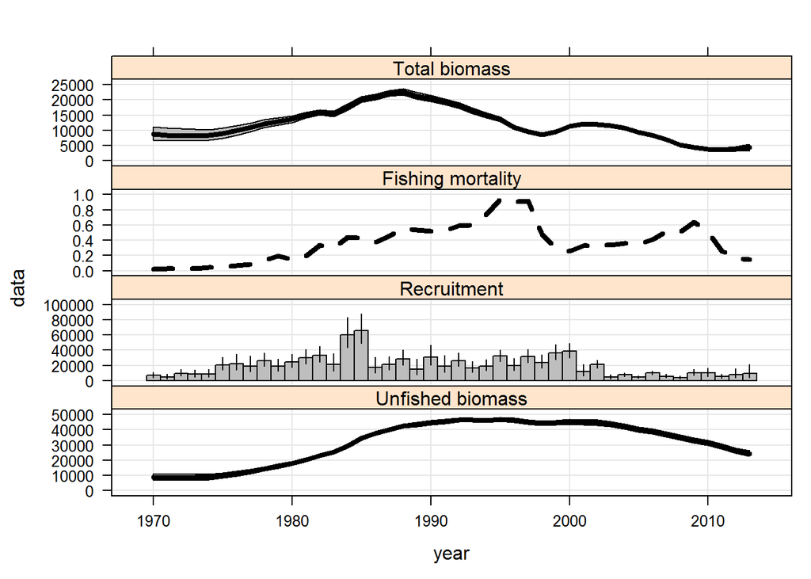